# Session12 - Inferential stats - FLER2110

Timo Roettger

8/11/2021

# Walkthrough

We will be looking at a familiar data set: the similarity data set from Winter and Matlock.

Let’s remind us on whats going on in the data.

```r
# Load our data set
sim <- read_csv("winter_matlock_2013_similarity.csv")
head(sim)
```

```
## # A tibble: 6 x 3
##   Sem       Phon      Distance
##   <chr>     <chr>        <dbl>
## 1 Different Similar         76
## 2 Different Different      110
## 3 Similar   Similar        214
## 4 Different Different       41
## 5 Different Different       78
## 6 Different Similar         87
```

Participants drew fictional villages on a map solely based on what they have read about the village (relative to another village). The researchers measured the `Distance` of the drawn villages. Village descriptions and names were either similar or different with respect to their phonological form (`Phon`) or their semantic properties (`Sem`).

## A simple linear model

Let’s predict `Distance` based on `Phon` and `Sem`.

```r
# linear model
xlm <- lm(Distance ~ Phon + Sem,
          data = sim)

summary(xlm)
```

```
##
## Call:
## lm(formula = Distance ~ Phon + Sem, data = sim)
##
## Residuals:
##     Min      1Q  Median      3Q     Max
## -79.350 -26.453  -4.167  19.536 138.833
##
## Coefficients:
##             Estimate Std. Error t value Pr(>|t|)
## (Intercept)   79.556      3.631  21.912   <2e-16 ***
## PhonSimilar    5.795      4.181   1.386   0.1667
## SemSimilar   -10.184      4.181  -2.435   0.0154 *
## ---
## Signif. codes:  0 '***' 0.001 '**' 0.01 '*' 0.05 '.' 0.1 ' ' 1
##
## Residual standard error: 39.81 on 360 degrees of freedom
##   (1 observation deleted due to missingness)
## Multiple R-squared:  0.02148,    Adjusted R-squared:  0.01604
## F-statistic: 3.951 on 2 and 360 DF,  p-value: 0.02008
```

We get a bunch of information. Now that we have learned about uncertainty and significance testing, we can interpret the whole model output. The model estimates that phonologically similar villages are drawn 5.795 units further away than phonologically different villages (the intercept). This difference is statistically not significant (p = 0.1667). So if the null hypothesis is true, i.e. phonological similarity has no impact on distance, than the obtained t-value (t = 1.386) or more extreme t-values are too likely for us to reject the null. Moreover, the model estimates that semantically similar villages are drawn 10.184 units closer than semantically different villages (the intercept). This difference is statistically significant (p = 0.0154). So if the null hypothesis is true, i.e. semantic similarity has no impact on distance, than the obtained t-value (t = -2.435) or more extreme t-values are unlikely enough for us to reject the null.

## Extract predictions

Let’s extract the models predictions for all combinations of `Phon` and `Sem`.

```r
# predict
## new df for prediction
newpreds <- tibble(expand.grid(Phon = unique(sim$Phon),
                               Sem = unique(sim$Sem)))

## predict based on model
sim_preds <- predict(xlm,
                     newpreds,
                     interval = 'confidence')

sim_predictions <- cbind(newpreds, sim_preds)
sim_predictions
```

```
##        Phon       Sem      fit      lwr      upr
## 1   Similar Different 85.35043 78.39001 92.31084
## 2 Different Different 79.55565 72.41572 86.69558
## 3   Similar   Similar 75.16676 68.02683 82.30669
## 4 Different   Similar 69.37199 62.12524 76.61874
```

## Plot predictions

Now we plot the model estimates and their 95% confidence intervals.

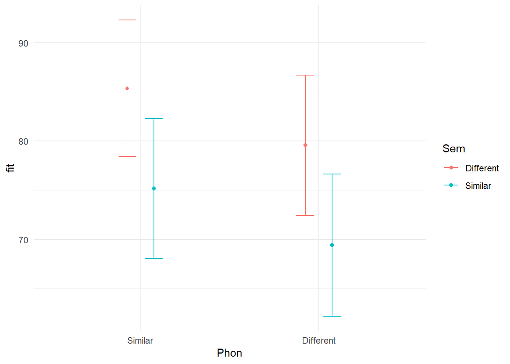

```r
sim_predictions %>%
  ggplot(aes(x = Phon,
             y = fit,
             color = Sem)) +
  geom_point(position = position_dodge(0.3)) +
  geom_errorbar(aes(ymin = lwr,
                    ymax = upr),
                position = position_dodge(0.3),
                width = 0.2) +
  theme_minimal()
```